# An Example of Using Function `estimateCounts`: Estimating the New Zealand Population

John Bryant

2015-10-21

# Introduction

# Preparing and inspecting data

For the purposes of this example, we treat the official estimates of population, in array `nz.popn`, as the truth. We use the various simulated datasets generated from `nz.popn` as data to try to recover the true population. The datasets are as follows.

[output not shown]

The data are in package `demdata`. The first step is to turn the data into counts arrays.

```r
library(demdata)
library(demest)
popn.true <- Counts(nz.popn)
nat <- Counts(nz.admin.nat)
health <- Counts(nz.admin.health)
school <- Counts(nz.admin.school)
survey <- Counts(nz.admin.survey)
```

# Setting up the model

We begin by specifying a model for the underlying population. The model is parsimonious, with the only interactions being between age and sex and between age and region, to help with convergence.

```r
popn.mod <- Model(y ~ Poisson(mean ~ age * sex + age * region + year,
                              exposure = FALSE),
                  region ~ Exch(robust = TRUE))
```

Next we specify data models and put them in a list. The list does not need names, since `estimateCounts` will use the names of the responses to match data models to datasets.

```r
nat.mod <- Model(nat ~ PoissonBinomial(prob = 0.98))
health.mod <- Model(health ~ Poisson(mean ~ age))
school.mod <- Model(school ~ PoissonBinomial(prob = 0.98))
survey.mod <- Model(survey ~ Binomial(prob = 0.05))
observation <- list(nat.mod, health.mod, school.mod, survey.mod)
```

We generate some starting values for the population estimates,

```r
y <- Counts(array(as.integer(health * 1.2),
                  dim = dim(health),
                  dimnames = dimnames(health)))
```

put the datasest in a named list,

```r
datasets <- list(nat = nat, health = health, school = school, survey = survey)
```

and generate a filename

```r
filename <- tempfile()
```

# Running the model

We can now run the model. We will only do a few iterations, to see what happens.

```r
set.seed(1)  ## for replicability
estimateCounts(popn.mod,
               y = y ,
               observation = observation,
               datasets = datasets,
               filename = filename,
               nBurnin = 10,
               nSim = 10)
```

```
#> results contained in file "/var/folders/1s/_44z6v_d7x1bgw47jzbwbx8r0000gn/T//Rtmper2mge/file1785c49d60b51"
```

```r
fetchSummary(filename)
```

```
#> --------------------------------------------------
#> Model:
#> y ~ Poisson(mean ~ age * sex + age * region + year, exposure = FALSE),
#> region ~ Exch(robust = TRUE)
#> dimensions: age, sex, region, year
#> --------------------------------------------------
#> y:
#> dimensions: age, sex, region, year
#> n cells: 5184
#> --------------------------------------------------
#> Observation models:
#> *nat*
#> nat ~ PoissonBinomial(prob = 0.98)
#> dimensions: age, sex, year
#> *health*
#> health ~ Poisson(mean ~ age)
#> dimensions: age, sex, region, year
#> *school*
#> school ~ PoissonBinomial(prob = 0.98)
#> dimensions: age, sex, region, year
#> *survey*
#> survey ~ Binomial(prob = 0.05)
#> dimensions: age, sex, region, year
#> --------------------------------------------------
#> Datasets:
#> *nat*
#> Object of class "Counts"
#> dimensions: age, sex, year
#> n cells: 324,  n missing: 0, integers: TRUE, n zeros: 0, median: 140522
#> *health*
#> Object of class "Counts"
#> dimensions: age, sex, region, year
#> n cells: 5184,  n missing: 0, integers: TRUE, n zeros: 0, median: 3576.5
#> *school*
#> Object of class "Counts"
#> dimensions: age, sex, region, year
#> n cells: 576,  n missing: 0, integers: TRUE, n zeros: 0, median: 5820
#> *survey*
#> Object of class "Counts"
#> dimensions: age, sex, region, year
```

[output cut: 30 more lines]

```
#> model.hyper.age:sex.sdObs                   5.2682470  FALSE
#> model.hyper.age:sex.sdTrend                 2.4732184  FALSE
#> model.hyper.age:region.trend                2.0366926   TRUE
#> model.hyper.age:region.sdObs               24.2359171  FALSE
#> model.hyper.age:region.sdTrend              3.1503514  FALSE
#> observation.health.likelihood.mean         12.3189659   TRUE
#> observation.health.prior.param.(Intercept)  1.0472401  FALSE
#> observation.health.prior.param.age          1.2877876   TRUE
#> observation.health.prior.sd                 0.9722255  FALSE
#> observation.health.hyper.age.trend          2.2473179   TRUE
#> observation.health.hyper.age.sdObs          1.5880544  FALSE
#> observation.health.hyper.age.sdTrend        3.4795462  FALSE
#> observation.survey.likelihood.prob          3.2219733   TRUE
#> observation.survey.prior.sd                       Inf  FALSE
#> --------------------------------------------------
```

Nothing has converged, which is to be expected, but the model did run. After some experimentation, we change the jump lengths for the Metropolis-Hastings updates slightly

```r
popn.mod <- Model(y ~ Poisson(mean ~ age * sex + age * region + year,
                              exposure = FALSE,
                              jump = 0.03),
                  region ~ Exch(robust = TRUE))
survey.mod <- Model(survey ~ Binomial(prob = 0.05,
                                      jump = 0.002))
observation <- list(nat.mod, health.mod, school.mod, survey.mod)
```

and rerun the model to convergence. Warning: the next step can take a long time.

```r
set.seed(1)  ## for replicability
estimateCounts(popn.mod,
               y = y ,
               observation = observation,
               datasets = datasets,
               filename = filename,
               nBurnin = 15000,
               nSim = 15000,
               nThin = 60)
```

```
#> results contained in file "/var/folders/1s/_44z6v_d7x1bgw47jzbwbx8r0000gn/T//Rtmper2mge/file1785c49d60b51"
```

```r
fetchSummary(filename)
```

```
#> --------------------------------------------------
#> Model:
#> y ~ Poisson(mean ~ age * sex + age * region + year, exposure = FALSE,
#>     jump = 0.03),
#> region ~ Exch(robust = TRUE)
#> dimensions: age, sex, region, year
#> --------------------------------------------------
#> y:
#> dimensions: age, sex, region, year
#> n cells: 5184
#> --------------------------------------------------
#> Observation models:
#> *nat*
#> nat ~ PoissonBinomial(prob = 0.98)
#> dimensions: age, sex, year
#> *health*
#> health ~ Poisson(mean ~ age)
#> dimensions: age, sex, region, year
#> *school*
#> school ~ PoissonBinomial(prob = 0.98)
#> dimensions: age, sex, region, year
#> *survey*
#> survey ~ Binomial(prob = 0.05, jump = 0.002)
#> dimensions: age, sex, region, year
#> --------------------------------------------------
#> Datasets:
#> *nat*
#> Object of class "Counts"
#> dimensions: age, sex, year
#> n cells: 324,  n missing: 0, integers: TRUE, n zeros: 0, median: 140522
#> *health*
#> Object of class "Counts"
#> dimensions: age, sex, region, year
#> n cells: 5184,  n missing: 0, integers: TRUE, n zeros: 0, median: 3576.5
#> *school*
#> Object of class "Counts"
#> dimensions: age, sex, region, year
#> n cells: 576,  n missing: 0, integers: TRUE, n zeros: 0, median: 5820
#> *survey*
#> Object of class "Counts"
```

[output cut: 31 more lines]

```
#> model.hyper.age:sex.sdObs                  1.5844553  FALSE
#> model.hyper.age:sex.sdTrend                2.4682257  FALSE
#> model.hyper.age:region.trend               1.5033637   TRUE
#> model.hyper.age:region.sdObs               1.3198997  FALSE
#> model.hyper.age:region.sdTrend             1.2218355  FALSE
#> observation.health.likelihood.mean         1.0812646   TRUE
#> observation.health.prior.param.(Intercept) 1.0114971  FALSE
#> observation.health.prior.param.age         1.0654255   TRUE
#> observation.health.prior.sd                1.0106479  FALSE
#> observation.health.hyper.age.trend         1.0222230   TRUE
#> observation.health.hyper.age.sdObs         1.0198673  FALSE
#> observation.health.hyper.age.sdTrend       1.0077023  FALSE
#> observation.survey.likelihood.prob         1.0183257   TRUE
#> observation.survey.prior.sd                1.2165405  FALSE
#> --------------------------------------------------
```

# Examining the population estimates

To see what has been estimated, we use function `listContents`,

```r
listContents(filename)
```

```
#>   model
#>     likelihood
#>       mean
#>       jumpMean
#>       noProposal
#>       acceptMean
#>     prior
#>       param
#>         (Intercept)
#>         age
#>         sex
#>         region
#>         year
#>         age:sex
#>         age:region
#>       descriptions
#>       scale
#>       sd
#>     hyper
#>       (Intercept)
#>       age
#>         trend
#>         coef
#>         sdObs
#>         sdTrend
#>       sex
#>       region
#>         mean
#>         sd
#>       year
#>         trend
#>         coef
#>         sdObs
#>         sdTrend
#>       age:sex
#>         trend
#>         coef
#>         sdObs
#>         sdTrend
#>       age:region
```

[output cut: 37 more lines]

```
#>         acceptSD
#>   datasets
#>     nat
#>     health
#>     school
#>     survey
#>   mcmc
#>   control
#>   final
#>   seed
#>
#>
#>
#>
#>
```

To extract the population estimates, we use

```r
popn.est <- fetch(filename, where = "y")
```

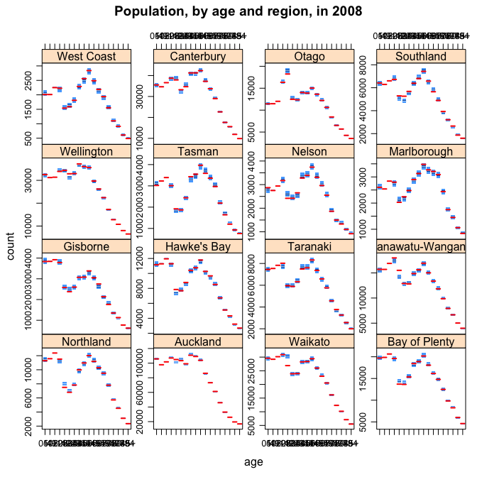

```r
dplot(~ age | region,
      data = popn.est,
      subarray = year == "2008",
      prob = c(0.025, 0.25, 0.5, 0.75, 0.975),
      scales = list(y = "free"),
      main = "Population, by age and region, in 2008",
      overlay = list(values = subarray(popn.true, year == "2008"),
                     col = "red",
                     lwd = 2))
```

The same, for 2014,

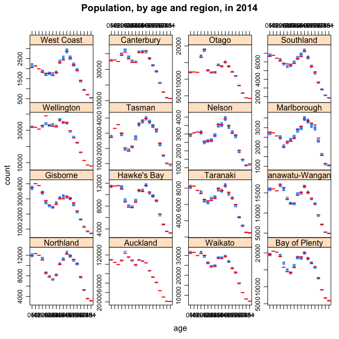

```r
dplot(~ age | region,
      data = popn.est,
      subarray = year == "2014",
      prob = c(0.025, 0.25, 0.5, 0.75, 0.975),
      scales = list(y = "free"),
      main = "Population, by age and region, in 2014",
      overlay = list(values = subarray(popn.true, year == "2014"),
                     col = "red",
                     lwd = 2))
```

Changes in the Auckland population (which was relatively poorly estimated) over time, females only,

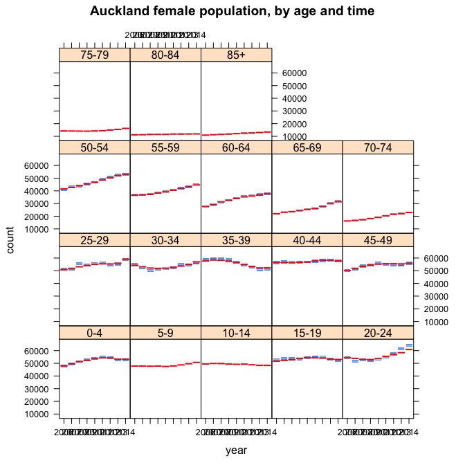

```r
dplot(~ year | age,
      data = popn.est,
      subarray = region == "Auckland" & sex == "Female",
      prob = c(0.025, 0.25, 0.5, 0.75, 0.975),
      main = "Auckland female population, by age and time",
      overlay = list(values = subarray(popn.true, region == "Auckland" & sex == "Female"),
                     col = "red",
                     lwd = 2))
```

Some numeric estimates

```r
nelson <- subarray(popn.est, region == "Nelson")
nelson <- collapseDimension(nelson, margin = "year")
nelson <- collapseIterations(nelson, prob = c(0.025, 0.5, 0.975))
round(nelson, -2)
```

```
#> An object of class "Counts"
#>
#> name:     year      quantile
#> length:   9         3
#> dimtype:  time      quantiles
#> dimscale: Intervals Quantiles
#>
#>       quantile
#> year    2.5%   50% 97.5%
#>   2006 44100 44500 45000
#>   2007 44300 44700 45200
#>   2008 45200 45600 46100
#>   2009 45500 46000 46400
#>   2010 46200 46600 47000
#>   2011 46700 47100 47600
#>   2012 47700 48100 48600
#>   2013 48100 48500 49000
#>   2014 48500 49000 49500
```

Converted to a data.frame

```r
as.data.frame(nelson, direction = "long")
```

```
#>    year quantile    count
#> 1  2006     2.5% 44100.45
#> 2  2007     2.5% 44309.68
#> 3  2008     2.5% 45227.00
#> 4  2009     2.5% 45514.00
#> 5  2010     2.5% 46155.12
#> 6  2011     2.5% 46651.90
#> 7  2012     2.5% 47694.12
#> 8  2013     2.5% 48065.23
#> 9  2014     2.5% 48500.58
#> 10 2006      50% 44534.00
#> 11 2007      50% 44730.00
#> 12 2008      50% 45643.00
#> 13 2009      50% 45959.50
#> 14 2010      50% 46580.00
#> 15 2011      50% 47121.00
#> 16 2012      50% 48143.00
#> 17 2013      50% 48525.00
#> 18 2014      50% 48974.00
#> 19 2006    97.5% 44980.00
#> 20 2007    97.5% 45211.55
#> 21 2008    97.5% 46113.52
#> 22 2009    97.5% 46423.55
#> 23 2010    97.5% 47021.55
#> 24 2011    97.5% 47576.33
#> 25 2012    97.5% 48617.55
#> 26 2013    97.5% 49008.10
#> 27 2014    97.5% 49450.52
```

# Examining coverage levels

Among other things, the model generates ‘coverage ratios’, that is, the number of people in the dataset divided by estimates of the true population. We take a look at coverage ratios for the health dataset in 2014. Since we in fact have the true population, we show that too, in red.

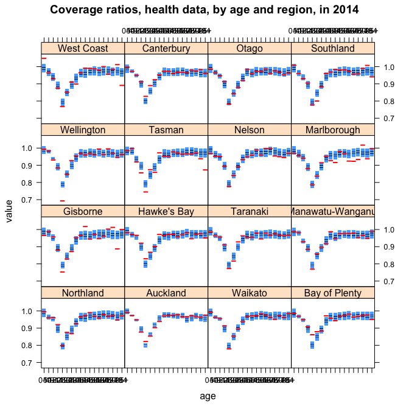

```r
coverage.health.est <- fetch(filename,
                         where = c("observation", "health", "likelihood", "mean"))
coverage.health.true <- health / popn.true
dplot(~ age | region,
      data = coverage.health.est,
      subarray = year == "2014",
      weights = popn.true,
      prob = c(0.025, 0.25, 0.5, 0.75, 0.975),
      main = "Coverage ratios, health data, by age and region, in 2014",
      overlay = list(values = subarray(coverage.health.true, year == "2014"),
                     col = "red",
                     lwd = 2))
```